# Homework 2

#### 5.4.11

Generate a sample of 1000 from an N(3, 2) distribution

```r
X = rnorm(n = 1000, mean = 3, sd = 2^0.5)
```

1. Calculate $\hat{F}_X$ for this example.

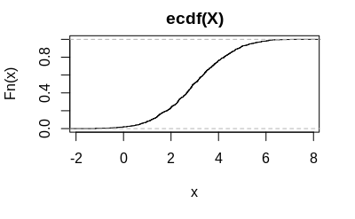

```r
F = ecdf(X)
plot(F)
```

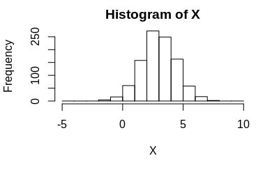

```r
hist(X, breaks = seq(-5, 10, by = 1))
```

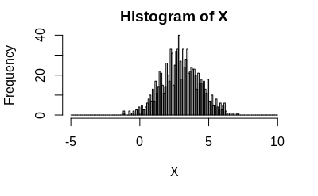

```r
hist(X, breaks = seq(-5, 10, by = 0.1))
```

#### 5.5.18

Generate a sample of 30 from an $N(10, 2)$ distribution and a sample of 1 from an $N(30, 2)$ distribution. Combine these together to make a single sample of 31.

```r
X = rnorm(n = 30, mean = 10, sd = 2^0.5)
Y = rnorm(n = 1, mean = 30, sd = 2^0.5)
Z = c(X, Y)
```

1. Produce a boxplot of these data.

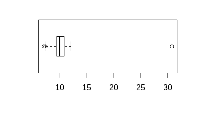

```r
boxplot(Z, horizontal = TRUE)
```

2. What do you notice about this plot?

The outlier is the number generated by $N(30, 2)$.

3. Based on the boxplot, what characteristic do you think would be appropriate to measure the location and spread of the distribution? Explain why.

Since the data is very skewed, the large outlier will contribute to the mean and standard deviation, which will make it not very representative of the data. We should use the median and interquartile range instead, because it will focus on the data that is closer to the centre.

#### 5.5.19

Generate a sample of 50 from a $\chi^2(1)$ distribution.

```r
X = rchisq(50, df = 1)
```

1. Produce a boxplot of these data.

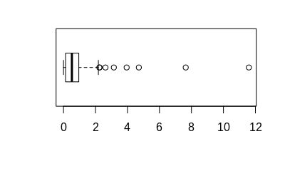

```r
boxplot(X, horizontal = TRUE)
```

2. What do you notice about this plot?

3. Based on the boxplot, what characteristic do you think would be appropriate to measure the location and spread of the distribution? Explain why.

Once again, we should use median and interquartile range because it will be representative of the data.